# Who Pushes the Welfare State? Public Opinion and the Elderly

POSC 459 — Social Welfare Politics and Policy · Week 14, Monday 30 November 2026 (asynchronous week)

*Accessible text version of the Week 14 Monday slides — same content in linear order, with no slide-scaling container. Each image carries a text description. Asynchronous week. Readings: Howard (2007), The Welfare State Nobody Knows, chapters 6 and 7.*

[figure not shown]

This deck walks you through Christopher Howard’s book *The Welfare State Nobody Knows*, chapters 6 and 7. Wednesday’s deck covers the other two readings.

*Photo: President Johnson signs the Medicare bill, July 30, 1965. White House photo, LBJ Library, public domain.*

## This week: no class meetings, one big deadline

1. **Your term paper is due Wednesday, December 2, at 11:59 p.m.** Upload a PDF to Canvas: 6–8 pages, double-spaced, APA citations, at least five new sources.
2. **If you used AI on the paper,** add a one-sentence disclosure or attach your downloaded PapyrusAI conversation.
3. **Read Howard, chapters 6 and 7,** with this deck. Wednesday’s deck covers *Who Cares* ch. 2 and Desmond ch. 6.
4. **There is no discussion paper this week.**
5. **Reading journal:** your last five entries are due Wednesday, December 9.
6. **We meet again Monday, December 7,** in GH 305.

*The final exam is Monday, December 14, 1:00–2:50 p.m., in GH 305. Bring a blue book. Questions this week? Email me.*

## How to use this deck (about 25 minutes)

The deck answers two questions from Howard’s book: - **Chapter 6:** Is the American welfare state small because Americans want it small? - **Chapter 7:** Does the government spend so much on older Americans because the elderly are politically powerful?

Each slide opens with **what happened**, shows the evidence, and ends with a shaded box, **Why it matters**, saying what you should now be able to argue. Read only the boxes and you have both arguments. Boxes marked **Use in your paper** hold claims with page numbers that fit the term paper. Page numbers are from Howard’s book.

## Glossary 1: the programs, groups, and surveys in this deck

| Term | What it is |
| --- | --- |
| **Social Security** | Monthly checks for retirees, survivors, and disabled workers, paid for by payroll taxes. The largest U.S. social program |
| **Medicare** | Health insurance for people 65 and older, created in 1965. **Part D**, a prescription drug benefit, was added in 2003 |
| **Medicaid** | Health coverage for low-income people, run by the states with federal money, also created in 1965 |
| **EITC** | Earned Income Tax Credit (1975): a tax refund for low-income people who work |
| **MCCA** | Medicare Catastrophic Coverage Act of 1988: added benefits to Medicare, paid for by retirees. Repealed in 1989 |
| **AARP** | The largest seniors’ organization, founded in 1958 (once the American Association of Retired Persons). Anyone 50 or older can join |
| **ISSP** | International Social Survey Program: polls that ask the same questions in many countries. Howard uses its 1996 survey |
| **GSS** | General Social Survey: a U.S. poll that has asked since the early 1970s whether government spends too little or too much on each program |

## Glossary 2: the ideas Howard uses

| Idea | What it means |
| --- | --- |
| **Net support** | The percent who want more spending minus the percent who want less. +40 means 40 points more people want more than want less (p. 117) |
| **Policy tools** | The forms government help takes: social insurance (Social Security), grants to states (Medicaid), tax breaks (the EITC), and rules on employers (pp. 109, 122) |
| **Trust in government** | The share of Americans who trust the national government to do the right thing most of the time (p. 122) |
| **Interest group** | An organization that pushes government for its members’ goals, such as AARP for older Americans |
| **Selective benefits** | Perks only members get, like discounts and insurance. Many people join a group for these, not for its politics (p. 135) |
| **Veto point** | A place where a change can be blocked: a committee, the other chamber, a veto, a court (p. 136) |
| **Loss aversion** | People fight harder to keep something they have than to gain something new (pp. 136–37) |
| **Policy feedback** | A program creates its own defenders, such as the retirees who rely on it (Pierson, Week 4) |

## Chapter 6 tests a common claim: Americans want a small welfare state

**What happened:** For decades, scholars argued that the U.S. welfare state stayed small because Americans value individualism and limited government more than Europeans do (pp. 109–11).

- **Howard’s evidence:** a 1996 survey that asked the same questions in many countries (the ISSP). Over 1,300 Americans answered (pp. 111–12).
- **His comparison:** the United States against six other rich democracies, namely Canada, Britain, Germany, Italy, Sweden, and Norway (p. 112).
- **What the claim predicts:** Americans should give government the least support on every question, and Swedes and Norwegians the most (p. 112).
- **His own caution:** public opinion “may not even be the most important” cause of policy (p. 109).

> **Why it matters:** If Americans support most of the welfare state, their values can’t explain why it looks the way it does. The next four slides test that.

*Source: Howard 2007, pp. 109–12.*

## Americans back help for the old and sick almost as much as Europeans

**What happened:** In the 1996 survey, Americans were less likely than people elsewhere to call most items a government responsibility, but the gap was small for the old and the sick (pp. 113–15).

[figure not shown]

> **Why it matters:** Americans and Europeans largely agree that government should care for the old and sick; they differ on how directly government should act. **Use in your paper.**

*Source: Howard 2007, table 6.1, p. 113, and pp. 114–15. The seven-nation average includes the U.S.*

## Most Americans chose more social spending over a tax cut

**What happened:** In 1996, asked to choose between more spending on social services and lower taxes, 60% of Americans chose spending, more than in every country but Britain (pp. 114–16).

- Asked about single programs, 77% of Americans wanted more spent on education, 68% on health, and 51% on pensions. No more than 10% wanted less for any of them (p. 115).
- Americans were choosy, though: only 28% wanted more spent on unemployment benefits (p. 113).

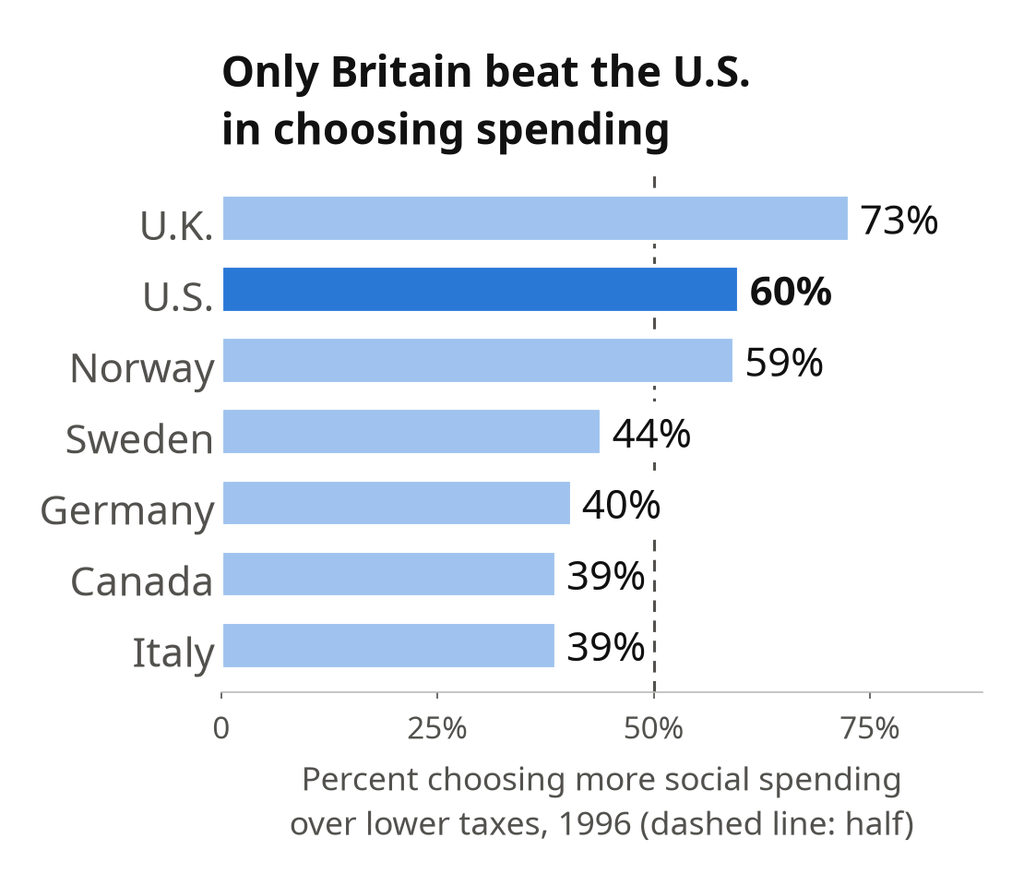

> **Why it matters:** Americans are not simply against taxes. When the trade-off is put to them directly, most choose social spending. **Use in your paper.**

*Source: Howard 2007, table 6.1, pp. 113–14, and pp. 115–16.*

## Support grew after 1996, and Republican voters shared it

**What happened:** The General Social Survey (GSS) asked Americans in 1996 and again in 2002 whether government spends too little or too much; support for more spending rose (pp. 117–18).

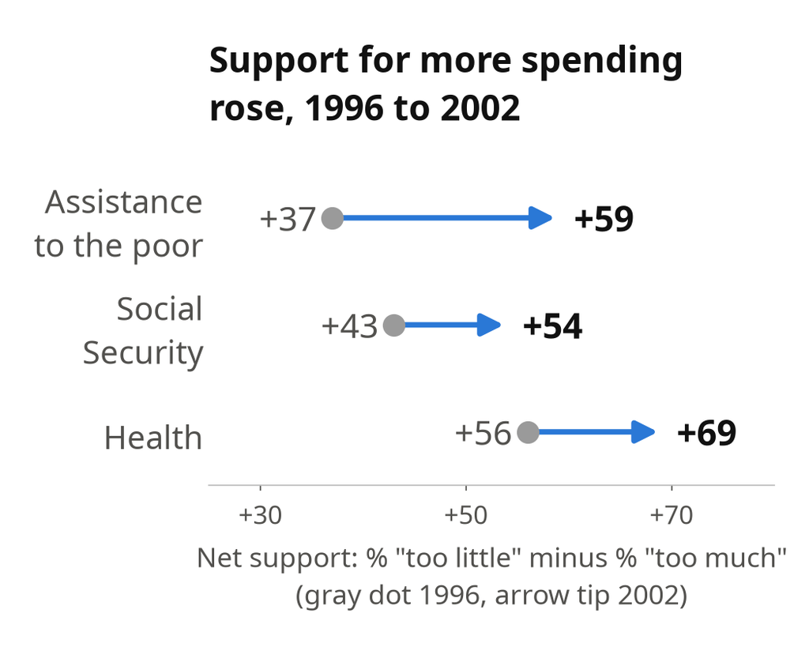

- **Republican voters** favored more spending on the big programs: net support of +38 for Social Security, +47 for health, and +46 for education (p. 119).
- **“Welfare” was the exception.** Its net support stayed negative from the 1970s to the 1990s, sometimes below −40, even as “assistance to the poor” scored positive (p. 118).

> **Why it matters:** Even Republican voters want the big programs kept or expanded. That helps explain why Republican officials cut welfare in 1981 and 1996 but helped expand the EITC and Medicaid (p. 119).

*Source: Howard 2007, pp. 117–19 (General Social Survey).*

## Howard’s verdict: Americans support their welfare state a bit less than Europeans, but still strongly

**What happened:** Howard sums up chapter 6 with a basketball comparison (p. 121).

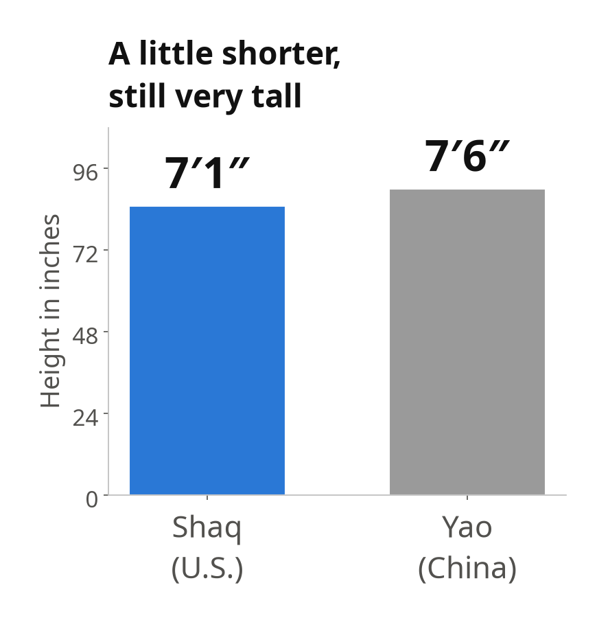

- Shaquille O’Neal (7 feet 1 inch) is shorter than Yao Ming (7 feet 6 inches), but “Shaq is still pretty tall” (p. 121).
- In the same way, Americans’ support for the welfare state is lower than Europeans’, but it is “broad and deep” (p. 121).
- U.S. policy matches that opinion: Social Security, Medicare, and Medicaid, the programs Americans back most, are the largest (p. 116).

> **Why it matters:** American values don’t block social spending. If a program people like stays small, look for another cause. **Use in your paper.**

*Source: Howard 2007, pp. 116, 121.*

## When Americans distrust Washington, Congress uses less visible tools

**What happened:** Trust in the national government fell from about three-quarters of Americans in the early 1960s to barely 20% in 1994, then recovered to over half by 2002 (p. 122).

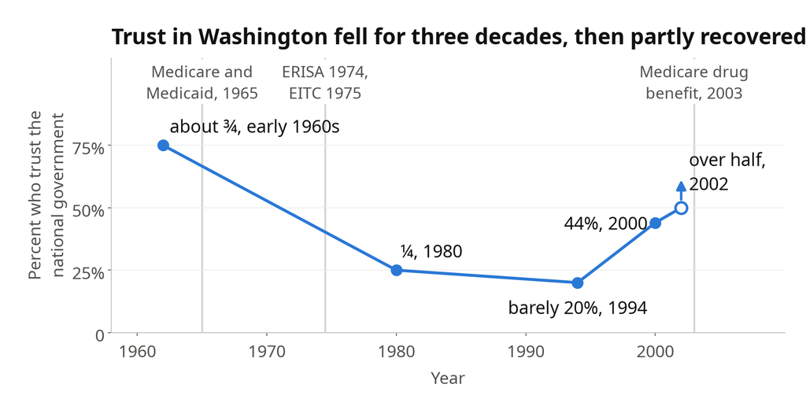

- **High trust, 1960s:** Congress created programs government runs or funds directly, such as Medicare, Medicaid, and Head Start (p. 122).
- **Low trust, 1970s–90s:** Congress passed tax breaks and rules on employers instead, like the EITC (1975) and the Americans with Disabilities Act (p. 123).

> **Why it matters:** If your program works through a tax credit or a mandate on employers, distrust of Washington may be part of the reason. Howard’s advice: “match the tool to the times” (p. 124). **Use in your paper.**

*Source: Howard 2007, pp. 122–24. His words drawn as numbers: “early 1960s” at 1962, “about three-quarters” at 75%, “over half” at 50%.*

## Chapter 7 tests a second claim: the elderly run social policy

**What happened:** Most federal social spending goes to older Americans, and critics blame the political power of the elderly and their lobby, AARP (pp. 125–26).

- **The critics:** economist Lawrence Kotlikoff quotes the phrase “greedy geezers” for retirees he says take money from young workers (p. 126).
- **AARP’s reputation:** Washington insiders rank it among the most powerful interest groups. It claimed 35 million members and took in $770 million in 2003 (p. 127).
- **Howard’s thesis:** “the political power of the elderly in the United States has been overstated” (p. 126).

> **Why it matters:** Howard tests the claim three ways: AARP’s record, how older people vote, and what younger people want. If younger Americans want the same programs, the elderly aren’t forcing anything on them.

*Source: Howard 2007, pp. 125–27.*

## AARP arrived after most of the programs were built

**What happened:** AARP was founded in 1958, mainly to sell insurance to retirees. Most of Social Security already existed, and AARP had almost no part in creating Medicare in 1965 (pp. 128–29).

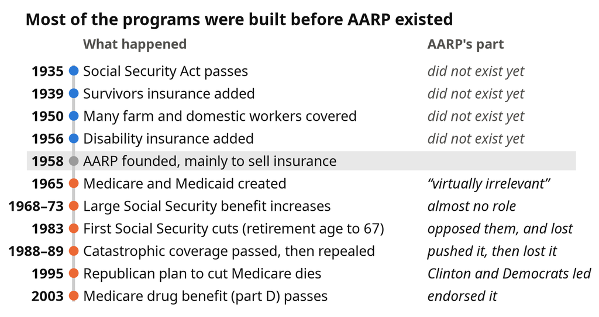

> **Why it matters:** “It makes more sense to say that the welfare state created AARP than vice versa” (p. 132). Big programs create the groups that later defend them: policy feedback. **Use in your paper.**

*Source: Howard 2007, pp. 128–32, 146; Theda Skocpol quoted on p. 128.*

## AARP’s one big push for new benefits backfired, 1988–89

**What happened:** In 1988, AARP helped pass the Medicare Catastrophic Coverage Act (MCCA), which added benefits for seniors. In 1989, after seniors protested, Congress repealed it (pp. 129–30).

- **Why seniors revolted:** retirees paid for the new benefits themselves, from about $50 a year for the poorest to $1,600 for the richest (p. 130).
- **The protests:** thousands wrote or showed up, and a crowd pounded on the car of Dan Rostenkowski, chair of the House Ways and Means Committee (p. 130).
- **AARP’s lesson:** in 1994 it refused to endorse President Clinton’s health plan (p. 130).

[figure not shown]

*Photo: Reagan signs the MCCA, July 1, 1988. White House photo, National Archives, public domain.*

> **Why it matters:** AARP is weak at winning new benefits. In Howard’s words, it is “decidedly weaker when it says ‘yes, more’” than when it says “no, not less” (p. 129).

*Source: Howard 2007, pp. 129–30.*

## AARP is better at blocking cuts, but it lost the biggest fight

**What happened:** In 1983, Congress passed the first cuts to Social Security, including raising the retirement age from 65 to 67. AARP opposed them and was “simply brushed aside” (pp. 131–32).

- **Where AARP did better:** in the 1990s, Medicare cuts fell mostly on doctors and hospitals, and by 1990 AARP had arguably become the most prominent group in Medicare politics (p. 131).
- **Why blocking is easier for any group:** the system has many veto points (“Losing in one house of Congress? Try the other”), and people fight harder to keep a benefit than to gain one (pp. 136–37).

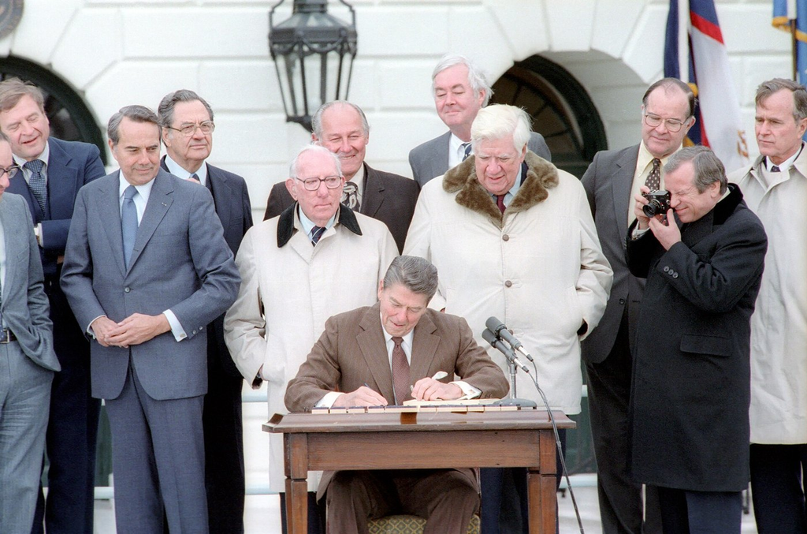

*Photo: Reagan signs the Social Security Amendments, April 20, 1983. White House photo, National Archives, public domain.*

> **Why it matters:** Defending an existing program is easier than winning a new one. That helps explain a program whose benefits survive but never grow. **Use in your paper.**

*Source: Howard 2007, pp. 131–37.*

## Why AARP’s size doesn’t turn into power

**What happened:** Howard finds three reasons AARP wins less than its 35 million members would suggest (pp. 132–36).

1. **Rival groups** also speak for seniors, some with opposite views, such as the 3-million-member Seniors Coalition (p. 132).
2. **Members disagree,** so AARP takes vague positions to avoid losing them (pp. 134–35).
3. **Most join for the perks:** discounts on travel and drugs, insurance, and a magazine, for $12.50 a year in dues (p. 135).

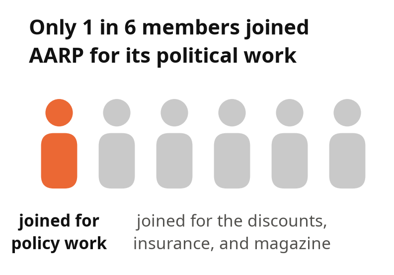

> **Why it matters:** A group held together by discounts can be huge and still hard to mobilize. Size alone doesn’t make an interest group powerful.

*Source: Howard 2007, pp. 132–36.*

## Older Americans vote more, but they are a minority of voters

**What happened:** From 1980 to 2000, two-thirds of Americans 65 and older said they voted for president, compared with about one in three adults aged 18 to 24 (p. 138).

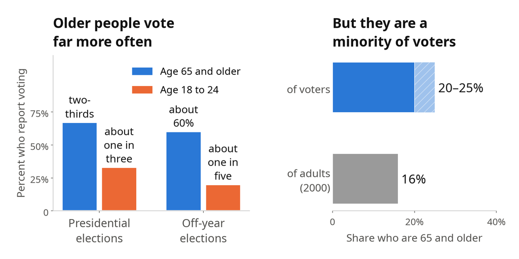

- In the 1950s through the 1970s, when Medicare passed and Social Security grew, older people voted no more often than anyone else (p. 138).

> **Why it matters:** The programs came first and high turnout came after. Political scientist Andrea Campbell found that the growth of the welfare state “helped to mobilize seniors politically” (p. 138): policy feedback at the ballot box.

*Source: Howard 2007, pp. 138–39. Bars are Howard’s words drawn as numbers: two-thirds at 67%, about one in three at 33%, about one in five at 20%.*

## Young and old Americans mostly want the same programs

**What happened:** Howard compares the views of young (18–34), middle-aged (35–64), and older (65 and over) adults in 2002 on eight kinds of spending and help (fig. 7.1, p. 140).

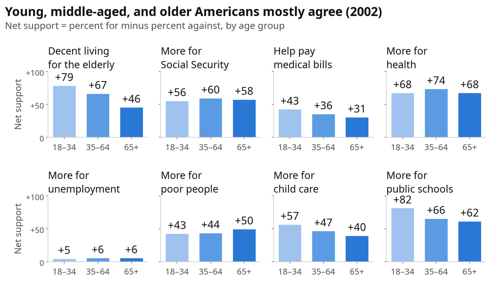

> **Why it matters:** Younger adults back a decent living for the elderly more strongly than older adults do (+79 against +46). The data show no “generational warfare” (pp. 140–41). **Use in your paper.**

*Source: Howard 2007, fig. 7.1, p. 140, and p. 141 (General Social Survey; National Election Studies).*

## Where age does matter: how much people care, and whether they vote on it

**What happened:** Older and younger Americans want similar programs, but older Americans care about them more, and that changes how they vote (pp. 143–44).

> **Why it matters:** Programs for everyone, like Social Security, create voters who defend them; programs for the poor mostly don’t. Spending on the elderly is “very important to the elderly and quite acceptable to everyone else” (p. 144). **Use in your paper.**

*Source: Howard 2007, pp. 142–44 (National Election Studies; exit polls; Citizen Participation Study).*

## The 2003 drug benefit had as much support from the young as the old

**What happened:** In 2003, Congress added a prescription drug benefit to Medicare (part D), first estimated to cost $400 billion over ten years (p. 145).

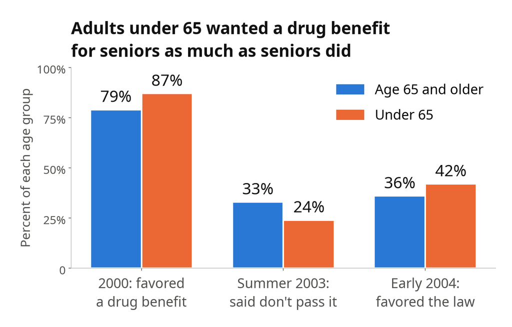

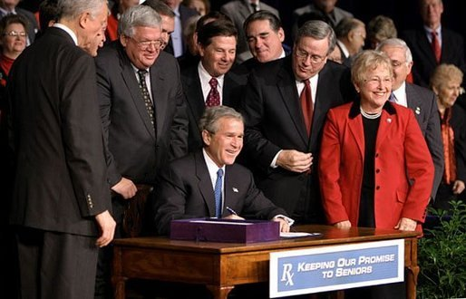

*Photo: Bush signs the drug benefit, December 8, 2003. Paul Morse, White House, public domain.*

- AARP backed the bill after polling people 45 and older, members or not. About 80,000 members quit in protest by July 2004 (p. 146).

> **Why it matters:** The biggest new benefit for seniors in decades had at least as much support from people under 65. AARP now aims to represent “the second half of life, not the fourth quarter” (p. 147).

*Source: Howard 2007, pp. 145–47.*

## Today’s two chapters in one slide

| The claim Howard tests | What he finds |
| --- | --- |
| Americans want a small welfare state (ch. 6) | They back the big programs nearly as much as Europeans, and 60% chose more social spending over a tax cut (pp. 113–21) |
| Distrust of Washington blocks new programs (ch. 6) | Distrust changes the tool: in low-trust years, Congress used tax breaks and rules on employers (pp. 122–24) |
| AARP gets what it wants (ch. 7) | AARP blocks some cuts but rarely wins new benefits, and it lost the 1983 Social Security fight (pp. 129–32) |
| The elderly force the young to pay for them (ch. 7) | The young support the same programs; by Howard’s test, “the elderly are not that powerful” (pp. 140–48) |

> **Why it matters:** Broad public support protects a program, and a group that cares intensely defends it from cuts. Programs for the poor have public support but few intense defenders, so their expansions have come from political leaders (pp. 144, 148–49). **Use in your paper.**

## Wednesday’s deck: business, labor, and the comfortable

Wednesday’s deck walks the week’s other two readings:

1. **Howard, *Who Cares*, chapter 2:** do business groups and labor unions speak up for poor people?
2. **Desmond, *Poverty, by America*, chapter 6:** how better-off Americans pull away from public services and keep opportunity for themselves.

It ends with a one-slide recap of today, a table comparing all four readings, and a checklist for your term paper.

*Reminder: your term paper is due Wednesday, December 2, at 11:59 p.m. Questions? Email me.*